# Biostat 203B Homework 1

Due Jan 26, 2024 @ 11:59PM

Author

Hiroyasu Ando, UID: 605948443

## Q1. Git/GitHub

**No handwritten homework reports are accepted for this course.** We work with Git and GitHub. Efficient and abundant use of Git, e.g., frequent and well-documented commits, is an important criterion for grading your homework.

1. Apply for the [Student Developer Pack](https://education.github.com/pack) at GitHub using your UCLA email. You’ll get GitHub Pro account for free (unlimited public and private repositories).

   **Answer:**

   I applied for the Student Developer Pack and got GitHub Pro account.

[figure not shown]

2. Create a **private** repository `biostat-203b-2024-winter` and add `Hua-Zhou` and TA team (`Tomoki-Okuno` for Lec 1; `jonathanhori` and `jasenzhang1` for Lec 80) as your collaborators with write permission.

   **Answer:**

   It’s done.

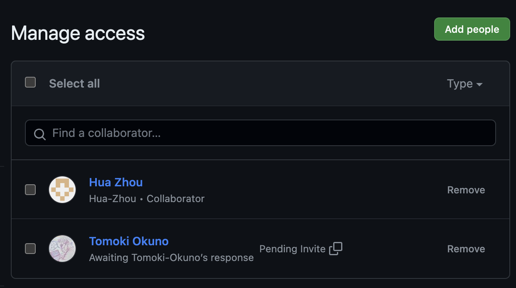

3. Top directories of the repository should be `hw1`, `hw2`, … Maintain two branches `main` and `develop`. The `develop` branch will be your main playground, the place where you develop solution (code) to homework problems and write up report. The `main` branch will be your presentation area. Submit your homework files (Quarto file `qmd`, `html` file converted by Quarto, all code and extra data sets to reproduce results) in the `main` branch.

   **Answer:**

   It’s done.

[figure not shown]

4. After each homework due date, course reader and instructor will check out your `main` branch for grading. Tag each of your homework submissions with tag names `hw1`, `hw2`, … Tagging time will be used as your submission time. That means if you tag your `hw1` submission after deadline, penalty points will be deducted for late submission.

   **Answer:**

   Okay.
5. After this course, you can make this repository public and use it to demonstrate your skill sets on job market.

   **Answer:**

   Okay.

## Q2. Data ethics training

This exercise (and later in this course) uses the [MIMIC-IV data v2.2](https://physionet.org/content/mimiciv/2.2/), a freely accessible critical care database developed by the MIT Lab for Computational Physiology. Follow the instructions at https://mimic.mit.edu/docs/gettingstarted/ to (1) complete the CITI `Data or Specimens Only Research` course and (2) obtain the PhysioNet credential for using the MIMIC-IV data. Display the verification links to your completion report and completion certificate here. **You must complete Q2 before working on the remaining questions.** (Hint: The CITI training takes a few hours and the PhysioNet credentialing takes a couple days; do not leave it to the last minute.)

**Answer:**

1. Completion report (CITI)

https://www.citiprogram.org/verify/?k9cad851b-7215-4e9d-84a9-93d8ee84720e-60469675

2. Completion certificate (CITI)

https://www.citiprogram.org/verify/?wfe307642-6687-49de-a08c-4155771715ed-60469675

3. PhysioNet credentialing

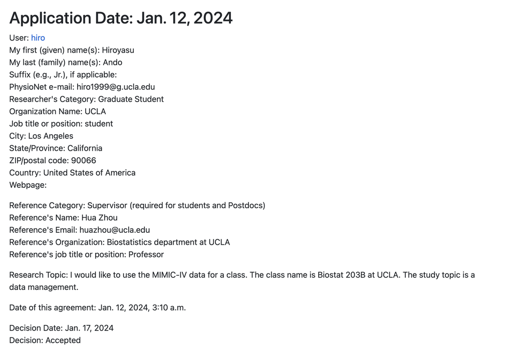

## Q3. Linux Shell Commands

1. Make the MIMIC v2.2 data available at location `~/mimic`.

```bash
ls -l ~/mimic/
```

```
total 48
-rw-rw-r--@  1 tomokiokuno  staff  13332 Jan  5  2023 CHANGELOG.txt
-rw-rw-r--@  1 tomokiokuno  staff   2518 Jan  5  2023 LICENSE.txt
-rw-rw-r--@  1 tomokiokuno  staff   2884 Jan  6  2023 SHA256SUMS.txt
drwxr-xr-x@ 24 tomokiokuno  staff    768 Jan 12 20:30 hosp
drwxr-xr-x@ 11 tomokiokuno  staff    352 Jan 12 20:30 icu
lrwxr-xr-x   1 tomokiokuno  staff     40 Jan 12 20:39 mimic-iv-2.2 -> /Users/tomokiokuno/203b-hw/mimic-iv-2.2/
```

Refer to the documentation https://physionet.org/content/mimiciv/2.2/ for details of data files. Please, do **not** put these data files into Git; they are big. Do **not** copy them into your directory. Do **not** decompress the gz data files. These create unnecessary big files and are not big-data-friendly practices. Read from the data folder `~/mimic` directly in following exercises.

Use Bash commands to answer following questions.

2. Display the contents in the folders `hosp` and `icu` using Bash command `ls -l`. Why are these data files distributed as `.csv.gz` files instead of `.csv` (comma separated values) files? Read the page https://mimic.mit.edu/docs/iv/ to understand what’s in each folder.

**Answer:**

Compressed files take up less storage space than uncompressed files and use less bandwidth when transferred over the network. This is why these data files are distributed as “.csv.gz” files instead of “.csv” files.

**hosp:**

```bash
ls -l ~/mimic/hosp
```

```
total 8859752
-rw-rw-r--@ 1 tomokiokuno  staff    15516088 Jan  5  2023 admissions.csv.gz
-rw-rw-r--@ 1 tomokiokuno  staff      427468 Jan  5  2023 d_hcpcs.csv.gz
-rw-rw-r--@ 1 tomokiokuno  staff      859438 Jan  5  2023 d_icd_diagnoses.csv.gz
-rw-rw-r--@ 1 tomokiokuno  staff      578517 Jan  5  2023 d_icd_procedures.csv.gz
-rw-rw-r--@ 1 tomokiokuno  staff       12900 Jan  5  2023 d_labitems.csv.gz
-rw-rw-r--@ 1 tomokiokuno  staff    25070720 Jan  5  2023 diagnoses_icd.csv.gz
-rw-rw-r--@ 1 tomokiokuno  staff     7426955 Jan  5  2023 drgcodes.csv.gz
-rw-rw-r--@ 1 tomokiokuno  staff   508524623 Jan  5  2023 emar.csv.gz
-rw-rw-r--@ 1 tomokiokuno  staff   471096030 Jan  5  2023 emar_detail.csv.gz
-rw-rw-r--@ 1 tomokiokuno  staff     1767138 Jan  5  2023 hcpcsevents.csv.gz
-rw-rw-r--@ 1 tomokiokuno  staff  1939088924 Jan  5  2023 labevents.csv.gz
-rw-rw-r--@ 1 tomokiokuno  staff    96698496 Jan  5  2023 microbiologyevents.csv.gz
-rw-rw-r--@ 1 tomokiokuno  staff    36124944 Jan  5  2023 omr.csv.gz
-rw-rw-r--@ 1 tomokiokuno  staff     2312631 Jan  5  2023 patients.csv.gz
-rw-rw-r--@ 1 tomokiokuno  staff   398753125 Jan  5  2023 pharmacy.csv.gz
-rw-rw-r--@ 1 tomokiokuno  staff   498505135 Jan  5  2023 poe.csv.gz
-rw-rw-r--@ 1 tomokiokuno  staff    25477219 Jan  5  2023 poe_detail.csv.gz
-rw-rw-r--@ 1 tomokiokuno  staff   458817415 Jan  5  2023 prescriptions.csv.gz
-rw-rw-r--@ 1 tomokiokuno  staff     6027067 Jan  5  2023 procedures_icd.csv.gz
-rw-rw-r--@ 1 tomokiokuno  staff      122507 Jan  5  2023 provider.csv.gz
-rw-rw-r--@ 1 tomokiokuno  staff     6781247 Jan  5  2023 services.csv.gz
-rw-rw-r--@ 1 tomokiokuno  staff    36158338 Jan  5  2023 transfers.csv.gz
```

**icu:**

```bash
ls -l ~/mimic/icu
```

```
total 6155968
-rw-rw-r--@ 1 tomokiokuno  staff       35893 Jan  5  2023 caregiver.csv.gz
-rw-rw-r--@ 1 tomokiokuno  staff  2467761053 Jan  5  2023 chartevents.csv.gz
-rw-rw-r--@ 1 tomokiokuno  staff       57476 Jan  5  2023 d_items.csv.gz
-rw-rw-r--@ 1 tomokiokuno  staff    45721062 Jan  5  2023 datetimeevents.csv.gz
-rw-rw-r--@ 1 tomokiokuno  staff     2614571 Jan  5  2023 icustays.csv.gz
-rw-rw-r--@ 1 tomokiokuno  staff   251962313 Jan  5  2023 ingredientevents.csv.gz
-rw-rw-r--@ 1 tomokiokuno  staff   324218488 Jan  5  2023 inputevents.csv.gz
-rw-rw-r--@ 1 tomokiokuno  staff    38747895 Jan  5  2023 outputevents.csv.gz
-rw-rw-r--@ 1 tomokiokuno  staff    20717852 Jan  5  2023 procedureevents.csv.gz
```

3. Briefly describe what Bash commands `zcat`, `zless`, `zmore`, and `zgrep` do.

   **zcat:**

   “zcat” can display the contents of compressed files without actually decompressing it.

   **zless:**

   “zless” can display the contents of compressed files one page at a time. When you scroll down or click down button, it will display the next line.

   **zmore:**

   “zmore” can display the contents of compressed files one page at a time. When you scroll down or click down button, it will display the next page.

   **zgrep:**

   “zgrep” can extract a specific string or pattern within a compressed files without actually decompressing it.
4. (Looping in Bash) What’s the output of the following bash script?

**Answer:**

This shows the file size, file name, and the date and time the file was last modified for each file in the folder “hosp” that starts with “a”, “l”, or “pa” and ends with “.gz”.

```bash
for datafile in ~/mimic/hosp/{a,l,pa}*.gz
  do
    ls -l $datafile
  done
```

```
-rw-rw-r--@ 1 tomokiokuno  staff  15516088 Jan  5  2023 /Users/tomokiokuno/mimic/hosp/admissions.csv.gz
-rw-rw-r--@ 1 tomokiokuno  staff  1939088924 Jan  5  2023 /Users/tomokiokuno/mimic/hosp/labevents.csv.gz
-rw-rw-r--@ 1 tomokiokuno  staff  2312631 Jan  5  2023 /Users/tomokiokuno/mimic/hosp/patients.csv.gz
```

Display the number of lines in each data file using a similar loop. (Hint: combine linux commands `zcat <` and `wc -l`.)

```bash
for datafile in ~/mimic/hosp/{a,l,pa}*.gz
  do
    echo $datafile
    zcat < $datafile | wc -l
  done
```

```
/Users/tomokiokuno/mimic/hosp/admissions.csv.gz
  431232
/Users/tomokiokuno/mimic/hosp/labevents.csv.gz
 118171368
/Users/tomokiokuno/mimic/hosp/patients.csv.gz
  299713
```

5. Display the first few lines of `admissions.csv.gz`. How many rows are in this data file? How many unique patients (identified by `subject_id`) are in this data file? Do they match the number of patients listed in the `patients.csv.gz` file? (Hint: combine Linux commands `zcat <`, `head`/`tail`, `awk`, `sort`, `uniq`, `wc`, and so on.)

**First few lines, admissions.csv.gz:**

```bash
zcat < ~/mimic/hosp/admissions.csv.gz | head -n 5
```

```
subject_id,hadm_id,admittime,dischtime,deathtime,admission_type,admit_provider_id,admission_location,discharge_location,insurance,language,marital_status,race,edregtime,edouttime,hospital_expire_flag
10000032,22595853,2180-05-06 22:23:00,2180-05-07 17:15:00,,URGENT,P874LG,TRANSFER FROM HOSPITAL,HOME,Other,ENGLISH,WIDOWED,WHITE,2180-05-06 19:17:00,2180-05-06 23:30:00,0
10000032,22841357,2180-06-26 18:27:00,2180-06-27 18:49:00,,EW EMER.,P09Q6Y,EMERGENCY ROOM,HOME,Medicaid,ENGLISH,WIDOWED,WHITE,2180-06-26 15:54:00,2180-06-26 21:31:00,0
10000032,25742920,2180-08-05 23:44:00,2180-08-07 17:50:00,,EW EMER.,P60CC5,EMERGENCY ROOM,HOSPICE,Medicaid,ENGLISH,WIDOWED,WHITE,2180-08-05 20:58:00,2180-08-06 01:44:00,0
10000032,29079034,2180-07-23 12:35:00,2180-07-25 17:55:00,,EW EMER.,P30KEH,EMERGENCY ROOM,HOME,Medicaid,ENGLISH,WIDOWED,WHITE,2180-07-23 05:54:00,2180-07-23 14:00:00,0
```

**Rows, admissions.csv.gz (including headers):**

```bash
zcat < ~/mimic/hosp/admissions.csv.gz | wc -l
```

```
  431232
```

**Unique patients, admissions.csv.gz:**

```bash
zcat < ~/mimic/hosp/admissions.csv.gz | awk -F, 'FNR > 1 { print $1 }' | \
sort | uniq | wc -l
```

```
  180733
```

**Patients, patients.csv.gz:**

```bash
zcat < ~/mimic/hosp/patients.csv.gz | awk -F, 'FNR > 1 { print $1 }' | wc -l
```

```
  299712
```

**Unique patients, patients.csv.gz:**

```bash
zcat < ~/mimic/hosp/patients.csv.gz | awk -F, 'FNR > 1 { print $1 }' |  \
sort | uniq | wc -l
```

```
  299712
```

**Answer:**

There are 431232 rows in the data file “admissions.csv.gz” (including headers). There are 180733 unique patients in the data file “admissions.csv.gz”. They do not match the number of patients listed in the patients.csv.gz file.

6. What are the possible values taken by each of the variable `admission_type`, `admission_location`, `insurance`, and `ethnicity`? Also report the count for each unique value of these variables. (Hint: combine Linux commands `zcat`, `head`/`tail`, `awk`, `uniq -c`, `wc`, and so on; skip the header line.

**admission_type:**

(possible values)

They are the possible values.

```bash
zcat < ~/mimic/hosp/admissions.csv.gz | awk -F, 'FNR > 1 { print $6 }' | \
sort | uniq
```

```
AMBULATORY OBSERVATION
DIRECT EMER.
DIRECT OBSERVATION
ELECTIVE
EU OBSERVATION
EW EMER.
OBSERVATION ADMIT
SURGICAL SAME DAY ADMISSION
URGENT
```

(possible number of values)

The possible number of values is 9.

```bash
zcat < ~/mimic/hosp/admissions.csv.gz | awk -F, 'FNR > 1 { print $6 }' | \
sort | uniq | wc -l
```

```
       9
```

(count for each unique value of these variables)

They are the count for each unique value of these variables.

```bash
zcat < ~/mimic/hosp/admissions.csv.gz | awk -F, 'FNR > 1 { print $6 }' | \
sort | uniq -c
```

```
6626 AMBULATORY OBSERVATION
19554 DIRECT EMER.
18707 DIRECT OBSERVATION
10565 ELECTIVE
94776 EU OBSERVATION
149413 EW EMER.
52668 OBSERVATION ADMIT
34231 SURGICAL SAME DAY ADMISSION
44691 URGENT
```

**admission_location:**

(possible values)

They are the possible values.

```bash
zcat < ~/mimic/hosp/admissions.csv.gz | awk -F, 'FNR > 1 { print $8 }' | \
sort | uniq
```

```
AMBULATORY SURGERY TRANSFER
CLINIC REFERRAL
EMERGENCY ROOM
INFORMATION NOT AVAILABLE
INTERNAL TRANSFER TO OR FROM PSYCH
PACU
PHYSICIAN REFERRAL
PROCEDURE SITE
TRANSFER FROM HOSPITAL
TRANSFER FROM SKILLED NURSING FACILITY
WALK-IN/SELF REFERRAL
```

(possible number of values)

The possible number of values is 11.

```bash
zcat < ~/mimic/hosp/admissions.csv.gz | awk -F, 'FNR > 1 { print $8 }' | \
sort | uniq | wc -l
```

```
      11
```

(count for each unique value of these variables)

They are the count for each unique value of these variables.

```bash
zcat < ~/mimic/hosp/admissions.csv.gz | awk -F, 'FNR > 1 { print $8 }' | \
sort | uniq -c
```

```
 185 AMBULATORY SURGERY TRANSFER
10008 CLINIC REFERRAL
232595 EMERGENCY ROOM
 359 INFORMATION NOT AVAILABLE
4205 INTERNAL TRANSFER TO OR FROM PSYCH
5479 PACU
114963 PHYSICIAN REFERRAL
7804 PROCEDURE SITE
35974 TRANSFER FROM HOSPITAL
3843 TRANSFER FROM SKILLED NURSING FACILITY
15816 WALK-IN/SELF REFERRAL
```

**insurance:**

(possible values)

They are the possible values.

```bash
zcat < ~/mimic/hosp/admissions.csv.gz | awk -F, 'FNR > 1 { print $10 }' | \
sort | uniq
```

```
Medicaid
Medicare
Other
```

(possible number of values)

The possible number of values is 3.

```bash
zcat < ~/mimic/hosp/admissions.csv.gz | awk -F, 'FNR > 1 { print $10 }' | \
sort | uniq | wc -l
```

```
       3
```

(count for each unique value of these variables)

They are the count for each unique value of these variables.

```bash
zcat < ~/mimic/hosp/admissions.csv.gz | awk -F, 'FNR > 1 { print $10 }' | \
sort | uniq -c
```

```
41330 Medicaid
160560 Medicare
229341 Other
```

**race:**

(possible values)

They are the possible values.

```bash
zcat < ~/mimic/hosp/admissions.csv.gz | awk -F, 'FNR > 1 { print $13 }' | \
sort | uniq
```

```
AMERICAN INDIAN/ALASKA NATIVE
ASIAN
ASIAN - ASIAN INDIAN
ASIAN - CHINESE
ASIAN - KOREAN
ASIAN - SOUTH EAST ASIAN
BLACK/AFRICAN
BLACK/AFRICAN AMERICAN
BLACK/CAPE VERDEAN
BLACK/CARIBBEAN ISLAND
HISPANIC OR LATINO
HISPANIC/LATINO - CENTRAL AMERICAN
HISPANIC/LATINO - COLUMBIAN
HISPANIC/LATINO - CUBAN
HISPANIC/LATINO - DOMINICAN
HISPANIC/LATINO - GUATEMALAN
HISPANIC/LATINO - HONDURAN
HISPANIC/LATINO - MEXICAN
HISPANIC/LATINO - PUERTO RICAN
HISPANIC/LATINO - SALVADORAN
MULTIPLE RACE/ETHNICITY
NATIVE HAWAIIAN OR OTHER PACIFIC ISLANDER
OTHER
PATIENT DECLINED TO ANSWER
PORTUGUESE
SOUTH AMERICAN
UNABLE TO OBTAIN
UNKNOWN
WHITE
WHITE - BRAZILIAN
WHITE - EASTERN EUROPEAN
WHITE - OTHER EUROPEAN
WHITE - RUSSIAN
```

(possible number of values)

The possible number of values is 33.

```bash
zcat < ~/mimic/hosp/admissions.csv.gz | awk -F, 'FNR > 1 { print $13 }' | \
sort | uniq | wc -l
```

```
      33
```

(count for each unique value of these variables)

They are the count for each unique value of these variables.

```bash
zcat < ~/mimic/hosp/admissions.csv.gz | awk -F, 'FNR > 1 { print $13 }' | \
sort | uniq -c
```

```
 919 AMERICAN INDIAN/ALASKA NATIVE
6156 ASIAN
1198 ASIAN - ASIAN INDIAN
5587 ASIAN - CHINESE
 506 ASIAN - KOREAN
1446 ASIAN - SOUTH EAST ASIAN
2530 BLACK/AFRICAN
59959 BLACK/AFRICAN AMERICAN
4765 BLACK/CAPE VERDEAN
2704 BLACK/CARIBBEAN ISLAND
7754 HISPANIC OR LATINO
 437 HISPANIC/LATINO - CENTRAL AMERICAN
 639 HISPANIC/LATINO - COLUMBIAN
 500 HISPANIC/LATINO - CUBAN
4383 HISPANIC/LATINO - DOMINICAN
```

[output cut: 18 more lines]

7. *To compress, or not to compress. That’s the question.* Let’s focus on the big data file `labevents.csv.gz`. Compare compressed gz file size to the uncompressed file size. Compare the run times of `zcat < ~/mimic/labevents.csv.gz | wc -l` versus `wc -l labevents.csv`. Discuss the trade off between storage and speed for big data files. (Hint: `gzip -dk < FILENAME.gz > ./FILENAME`. Remember to delete the large `labevents.csv` file after the exercise.)

```bash
gzip -dk < ~/mimic/hosp/labevents.csv.gz > ~/mimic/hosp/labevents.csv
```

**Compressed gz file size:**

```bash
ls -lh ~/mimic/hosp/labevents.csv.gz
```

```
-rw-rw-r--@ 1 tomokiokuno  staff   1.8G Jan  5  2023 /Users/tomokiokuno/mimic/hosp/labevents.csv.gz
```

**Uncompressed file size:**

```bash
ls -lh ~/mimic/hosp/labevents.csv
```

```
-rw-r--r--  1 tomokiokuno  staff    13G Feb  3 23:20 /Users/tomokiokuno/mimic/hosp/labevents.csv
```

**Run times of compressed gz file:**

```bash
time zcat < ~/mimic/hosp/labevents.csv.gz | wc -l
```

```
 118171368

real    0m17.052s
user    0m24.694s
sys 0m1.734s
```

**Run times of uncompressed file:**

```bash
time wc -l ~/mimic/hosp/labevents.csv
```

```
 118171368 /Users/tomokiokuno/mimic/hosp/labevents.csv

real    0m16.484s
user    0m14.084s
sys 0m1.481s
```

```bash
rm ~/mimic/hosp/labevents.csv
```

## Q4. Who’s popular in Price and Prejudice

1. You and your friend just have finished reading *Pride and Prejudice* by Jane Austen. Among the four main characters in the book, Elizabeth, Jane, Lydia, and Darcy, your friend thinks that Darcy was the most mentioned. You, however, are certain it was Elizabeth. Obtain the full text of the novel from http://www.gutenberg.org/cache/epub/42671/pg42671.txt and save to your local folder.

```bash
wget -nc http://www.gutenberg.org/cache/epub/42671/pg42671.txt
```

[output not shown]

##### Explain what `wget -nc` does. Do **not** put this text file `pg42671.txt` in Git.

**Explanation:**

“wget” downloads files from some URL. “-nc” means only if the file doesn’t already exist locally or if the local file has to be updated, the file will be downloaded.

Complete the following loop to tabulate the number of times each of the four characters is mentioned using Linux commands.

**Answer:**

The names of Elizabeth, Jane, Lydia, and Darcy were mentioned 634, 293, 171, and 418 times. Elizabeth was the most mentioned.

```bash
# wget -nc http://www.gutenberg.org/cache/epub/42671/pg42671.txt

for char in Elizabeth Jane Lydia Darcy
  do
    echo $char:
    grep -o -i $char pg42671.txt | wc -l
  done
```

```
Elizabeth:
     634
Jane:
     293
Lydia:
     171
Darcy:
     418
```

2. What’s the difference between the following two commands?

```bash
echo 'hello, world' > test1.txt
```

and

```bash
echo 'hello, world' >> test2.txt
```

**Answer**

**echo ‘hello, world’ > test1.txt:**

This command will create or overwrite a file called “test1.txt” and write “hello, world” in it.

**echo ‘hello, world’ >> test2.txt:**

This command will append “hello, world” in the last line of the file in the existing “test2.txt” file. If the “test2.txt” file does not exist, this command makes “test2.txt” and write “hello, world” in it.

3. Using your favorite text editor (e.g., `vi`), type the following and save the file as `middle.sh`:

```bash
#!/bin/sh
# Select lines from the middle of a file.
# Usage: bash middle.sh filename end_line num_lines
head -n "$2" "$1" | tail -n "$3"
```

Using `chmod` to make the file executable by the owner, and run

```bash
chmod +x middle.sh
```

```bash
./middle.sh pg42671.txt 20 5
```

```
Editor: R. W. Chapman

Release date: May 9, 2013 [eBook #42671]

Language: English
```

Explain the output. Explain the meaning of `"$1"`, `"$2"`, and `"$3"` in this shell script. Why do we need the first line of the shell script?

**Explanation:**

This script takes the first 20 lines of the file “pg42671.txt” and then takes the last 5 lines of the first 20 lines, which is the output.

$1 specifies a file. $2 specifies the end line you extract. $3 specifies the number of lines you extract. The first line of the shell script is called “shebang” and it tells the computer which interpreter to use to execute the script.

## Q5. More fun with Linux

Try following commands in Bash and interpret the results: `cal`, `cal 2024`, `cal 9 1752` (anything unusual?), `date`, `hostname`, `arch`, `uname -a`, `uptime`, `who am i`, `who`, `w`, `id`, `last | head`, `echo {con,pre}{sent,fer}{s,ed}`, `time sleep 5`, `history | tail`.

**cal**

This command displays a calendar of the current month.

```bash
cal
```

```
   February 2024
Su Mo Tu We Th Fr Sa
             1  2 _ _3
 4  5  6  7  8  9 10
11 12 13 14 15 16 17
18 19 20 21 22 23 24
25 26 27 28 29
```

**cal 2024**

This command displays a calendar of the year 2024.

```bash
cal 2024
```

```
                            2024
      January               February               March
Su Mo Tu We Th Fr Sa  Su Mo Tu We Th Fr Sa  Su Mo Tu We Th Fr Sa
    1  2  3  4  5  6               1  2 _ _3                  1  2
 7  8  9 10 11 12 13   4  5  6  7  8  9 10   3  4  5  6  7  8  9
14 15 16 17 18 19 20  11 12 13 14 15 16 17  10 11 12 13 14 15 16
21 22 23 24 25 26 27  18 19 20 21 22 23 24  17 18 19 20 21 22 23
28 29 30 31           25 26 27 28 29        24 25 26 27 28 29 30
                                            31

       April                  May                   June
Su Mo Tu We Th Fr Sa  Su Mo Tu We Th Fr Sa  Su Mo Tu We Th Fr Sa
    1  2  3  4  5  6            1  2  3  4                     1
 7  8  9 10 11 12 13   5  6  7  8  9 10 11   2  3  4  5  6  7  8
14 15 16 17 18 19 20  12 13 14 15 16 17 18   9 10 11 12 13 14 15
21 22 23 24 25 26 27  19 20 21 22 23 24 25  16 17 18 19 20 21 22
28 29 30              26 27 28 29 30 31     23 24 25 26 27 28 29
                                            30

        July                 August              September
Su Mo Tu We Th Fr Sa  Su Mo Tu We Th Fr Sa  Su Mo Tu We Th Fr Sa
    1  2  3  4  5  6               1  2  3   1  2  3  4  5  6  7
 7  8  9 10 11 12 13   4  5  6  7  8  9 10   8  9 10 11 12 13 14
14 15 16 17 18 19 20  11 12 13 14 15 16 17  15 16 17 18 19 20 21
21 22 23 24 25 26 27  18 19 20 21 22 23 24  22 23 24 25 26 27 28
28 29 30 31           25 26 27 28 29 30 31  29 30


      October               November              December
Su Mo Tu We Th Fr Sa  Su Mo Tu We Th Fr Sa  Su Mo Tu We Th Fr Sa
       1  2  3  4  5                  1  2   1  2  3  4  5  6  7
 6  7  8  9 10 11 12   3  4  5  6  7  8  9   8  9 10 11 12 13 14
13 14 15 16 17 18 19  10 11 12 13 14 15 16  15 16 17 18 19 20 21
20 21 22 23 24 25 26  17 18 19 20 21 22 23  22 23 24 25 26 27 28
27 28 29 30 31        24 25 26 27 28 29 30  29 30 31
```

**cal 9 1752**

This command displays a calendar of the year 1752, September. This is unusual because September 1752 had only 19 days.

```bash
cal 9 1752
```

```
   September 1752
Su Mo Tu We Th Fr Sa
       1  2 14 15 16
17 18 19 20 21 22 23
24 25 26 27 28 29 30
```

**date**

This command displays the current date and time.

```bash
date
```

```
Sat Feb  3 23:20:59 PST 2024
```

**hostname**

This command displays the name of the host (computer).

```bash
hostname
```

```
Tomokis-MacBook-Air-3.local
```

**arch**

This command displays the architecture of the computer.

```bash
arch
```

```
arm64
```

**uname -a**

This command displays the operating system, kernel version, hostname, date and time of the last kernel built, the machine architecture, and so on.

```bash
uname -a
```

```
Darwin Tomokis-MacBook-Air-3.local 23.1.0 Darwin Kernel Version 23.1.0: Mon Oct  9 21:28:12 PDT 2023; root:xnu-10002.41.9~6/RELEASE_ARM64_T8103 arm64
```

**uptime**

This command displays the current time, how long the computer has been running, how many users are currently logged on, and the system load averages for the past 1, 5, and 15 minutes.

```bash
uptime
```

```
23:20  up 8 days,  6:46, 6 users, load averages: 4.14 4.05 4.08
```

**who am i**

This command usually displays the username, terminal, and date and time of the last log in.

```bash
who am i
```

```
tomokiokuno                   Feb  3 23:20
```

**who**

This command displays the information about the currently logged in user, such as username, terminal, date, and time of the last login.

```bash
who
```

```
tomokiokuno      console      Jan 26 16:35
tomokiokuno      ttys000      Jan 26 16:36
tomokiokuno      ttys002      Jan 26 16:36
tomokiokuno      ttys003      Jan 26 16:36
tomokiokuno      ttys004      Jan 26 16:36
tomokiokuno      ttys005      Jan 26 16:36
```

**w**

In the first line, this command displays the current time, how long the computer has been running, how many users are currently logged on, and the system load averages for the past 1, 5, and 15 minutes. In the subsequent lines, this command displays the information about the currently logged in user, such as username, terminal, log-in time, idle time, current process, and command-line shells.

```bash
w | cat -v
```

```
23:20  up 8 days,  6:46, 6 users, load averages: 4.14 4.05 4.08
USER     TTY      FROM              LOGIN@  IDLE WHAT
tomokiokuno console  -                26Jan24 8days -
tomokiokuno s000     -                26Jan24    13 -bash
tomokiokuno s002     -                26Jan24 23:23 -bash
tomokiokuno s003     -                26Jan24 23:23 -bash
tomokiokuno s004     -                26Jan24 23:23 -bash
tomokiokuno s005     -                26Jan24 23:23 -bash
```

**id**

This command displays the user and group information for the current user.

```bash
id
```

```
uid=501(tomokiokuno) gid=20(staff) groups=20(staff),12(everyone),61(localaccounts),79(_appserverusr),80(admin),81(_appserveradm),98(_lpadmin),33(_appstore),100(_lpoperator),204(_developer),250(_analyticsusers),395(com.apple.access_ftp),398(com.apple.access_screensharing),399(com.apple.access_ssh),40…
```

**last | head**

*last* command displays the information about the last logged in users. *head* command is used to display the first few lines of the output. So, “last | head” displays the information about the recent (10) last logged in users.

```bash
last | head
```

```
tomokiokuno ttys005                         Fri Jan 26 16:36   still logged in
tomokiokuno ttys004                         Fri Jan 26 16:36   still logged in
tomokiokuno ttys003                         Fri Jan 26 16:36   still logged in
tomokiokuno ttys002                         Fri Jan 26 16:36   still logged in
tomokiokuno ttys001                         Fri Jan 26 16:36 - 16:36  (00:00)
tomokiokuno ttys000                         Fri Jan 26 16:36   still logged in
tomokiokuno console                         Fri Jan 26 16:35   still logged in
reboot time                                Fri Jan 26 16:35
tomokiokuno ttys013                         Thu Jan 25 12:25 - 12:25  (00:00)
tomokiokuno ttys009                         Thu Jan 25 01:32 - 01:32  (00:00)
```

**echo {con,pre}{sent,fer}{s,ed}**

This command displays all the possible combinations of the words “con” or “pre” with the words “sent” or “fer” with the words “s” or “ed”.

```bash
echo {con,pre}{sent,fer}{s,ed}
```

```
consents consented confers confered presents presented prefers prefered
```

**time sleep 5**

This command displays the time it takes to run the command “sleep 5” by a system, user and real time.

```bash
time sleep 5
```

```
real    0m5.006s
user    0m0.000s
sys 0m0.001s
```

**history | tail**

This command usually displays the last 10 commands you have run.

```bash
history | tail
```

[output not shown]

## Q6. Book

1. Git clone the repository https://github.com/christophergandrud/Rep-Res-Book for the book *Reproducible Research with R and RStudio* to your local machine.

**Answer:**

I did it.

[figure not shown]

2. Open the project by clicking `rep-res-3rd-edition.Rproj` and compile the book by clicking `Build Book` in the `Build` panel of RStudio. (Hint: I was able to build `git_book` and `epub_book` but not `pdf_book`.)

**Answer:**

I did it.

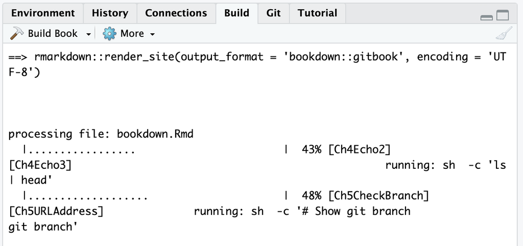

The point of this exercise is (1) to get the book for free and (2) to see an example how a complicated project such as a book can be organized in a reproducible way.

For grading purpose, include a screenshot of Section 4.1.5 of the book here.

**Answer:**

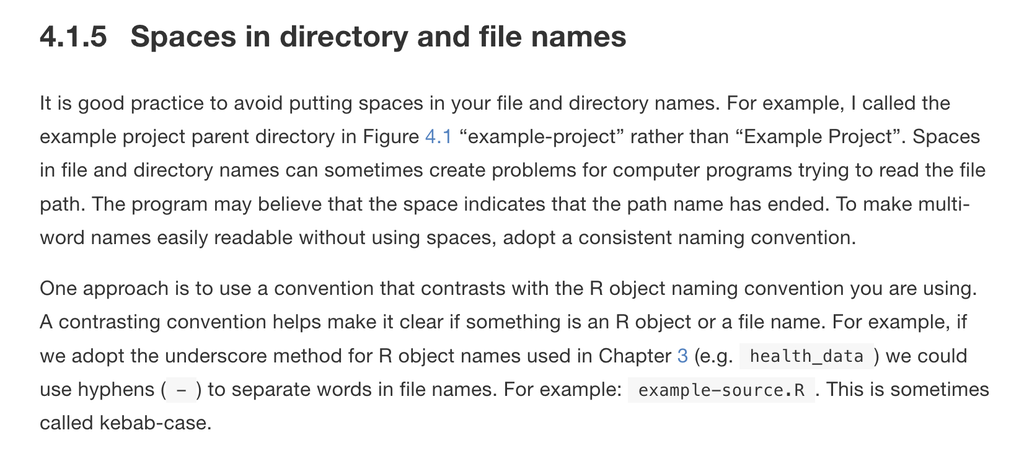